# PhenEndo

Richa Batra

June 30, 2018

# 1 Endotyping with R Markdown

This is an R Markdown document **to study endotypes targeted for questionaire or other biomedical records**. Markdown is a simple formatting syntax for authoring HTML, PDF, and MS Word documents. For more details on using R Markdown see http://rmarkdown.rstudio.com.

# 2 Data visualization

## 2.1 Heatmap

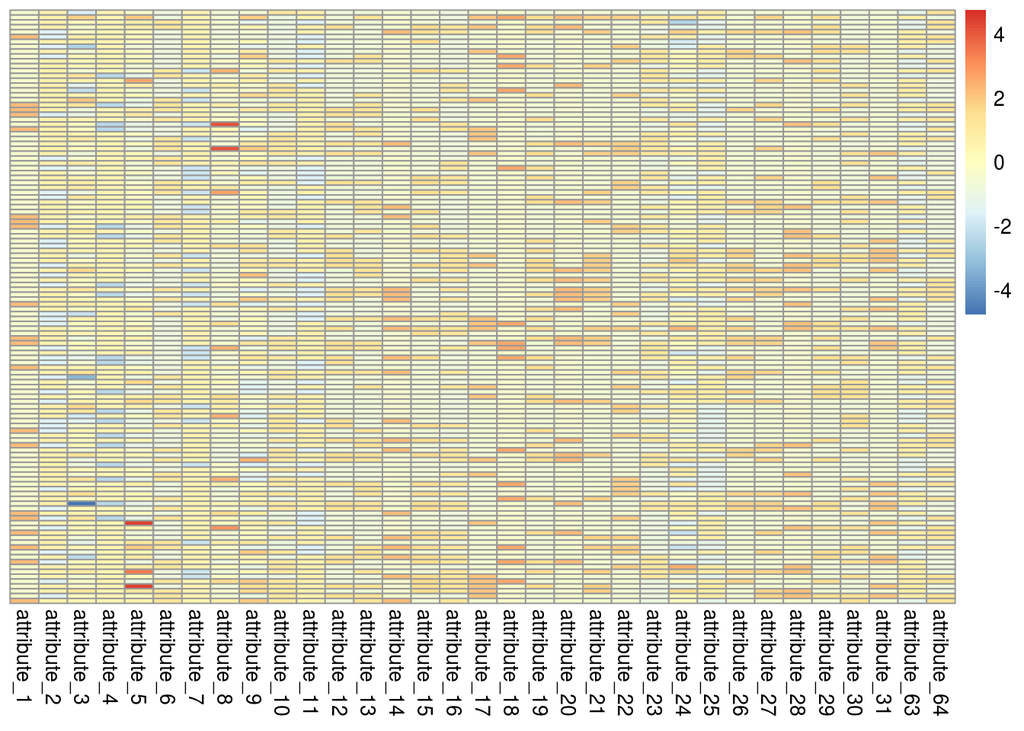

## 2.2 Each attribute

**Interpretation** in many of these plots one can see the imbalance in the binary variables, for instance attribute_1, attribute_4, attribute_7 and so on. These highly biased sets add to the noise in the data. On the other hand, if they co-occur they can be the deciding factor for the clustering algorithms. See next section on FAMD.

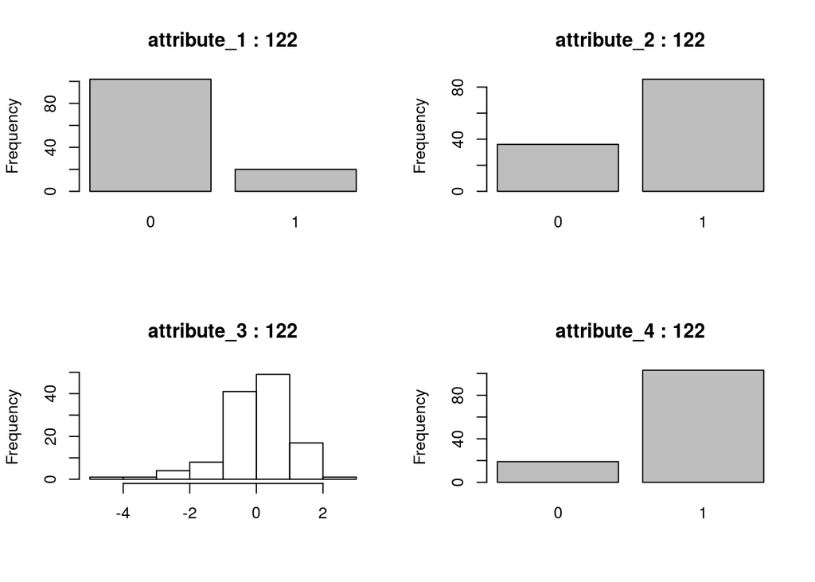

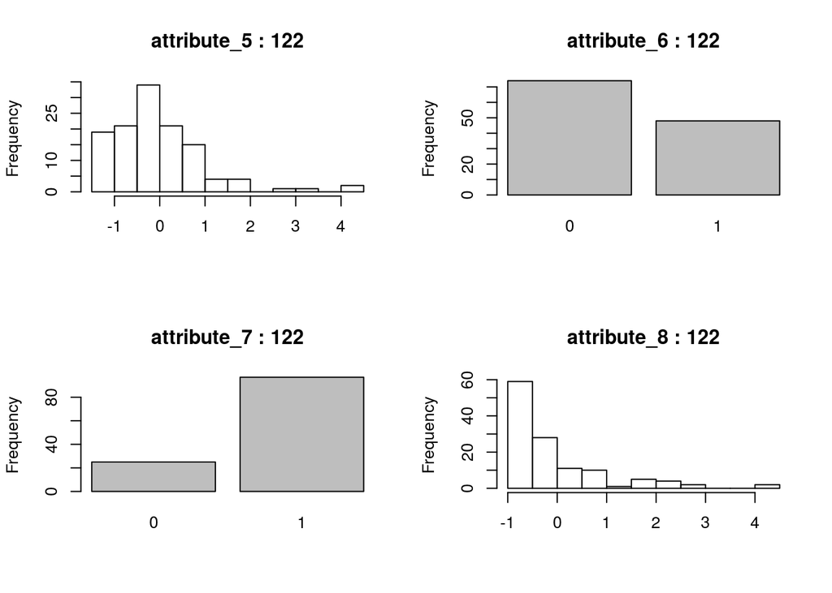

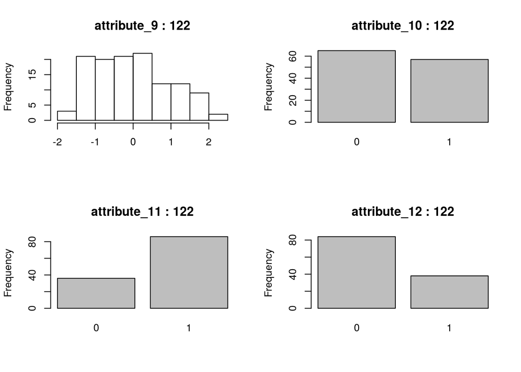

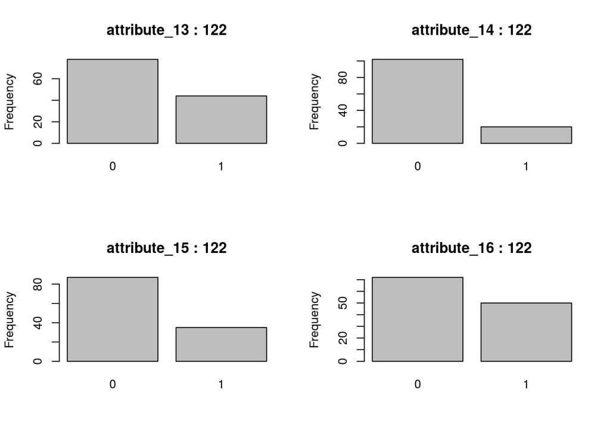

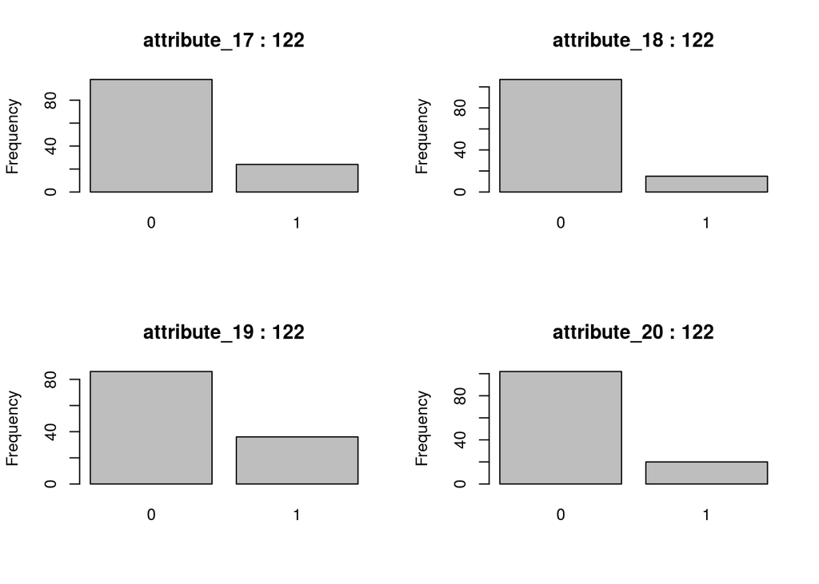

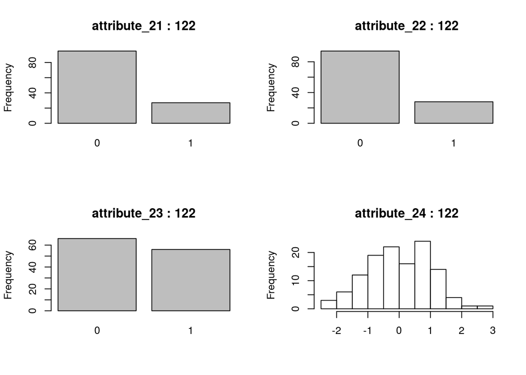

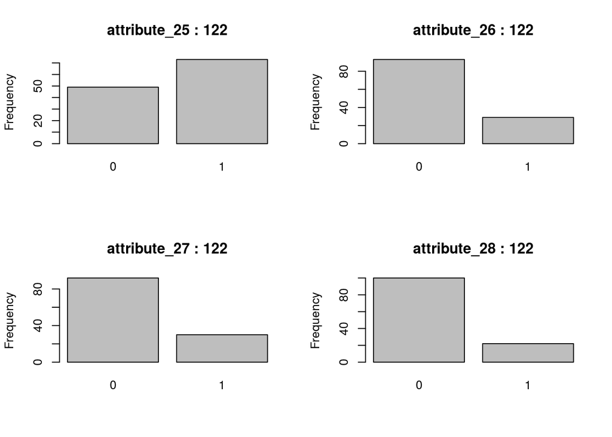

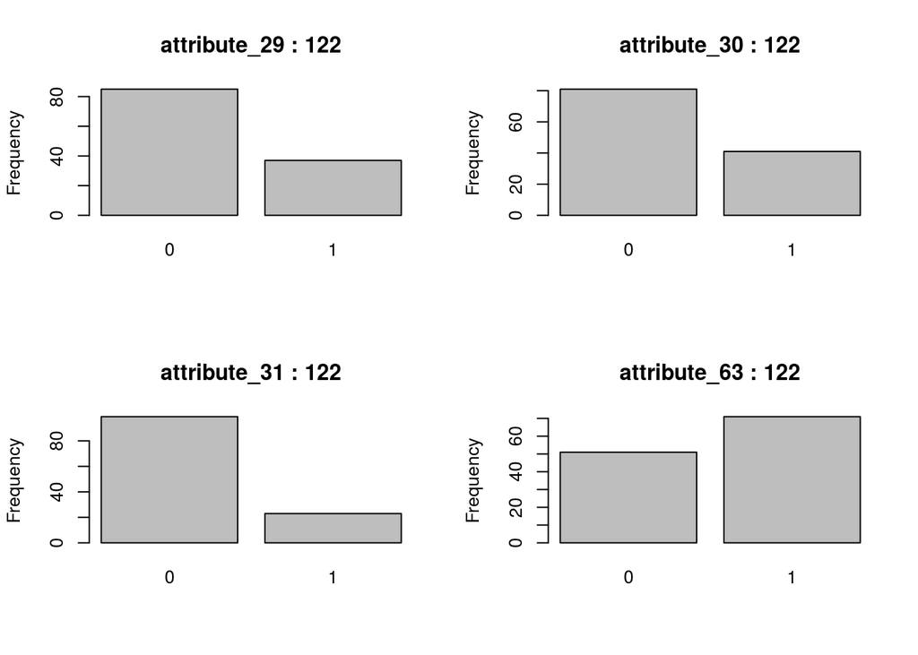

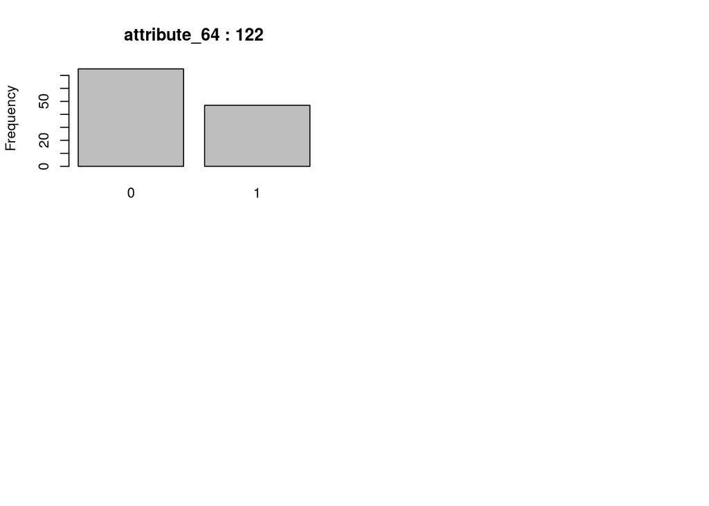

## 2.3 FAMD

Here the plot with qualitative varibles is particularly interesting. If you notice that many of the levels on the right are with value 1. Showing that many attributes are dependent and presence of a certain attribute co-occur with other attributes.

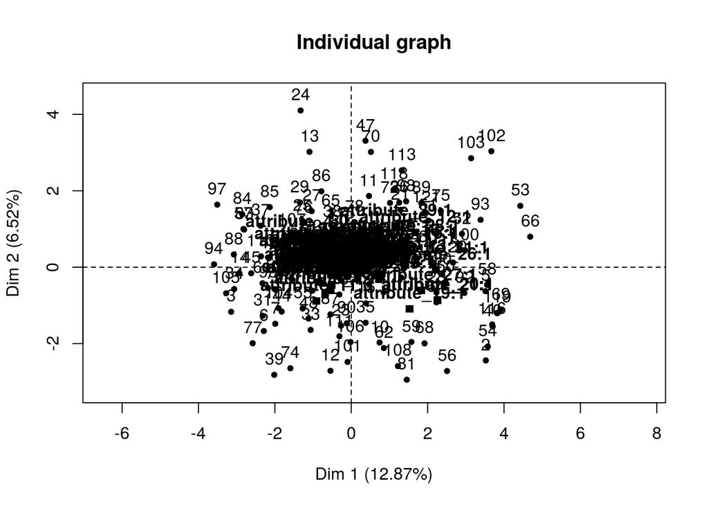

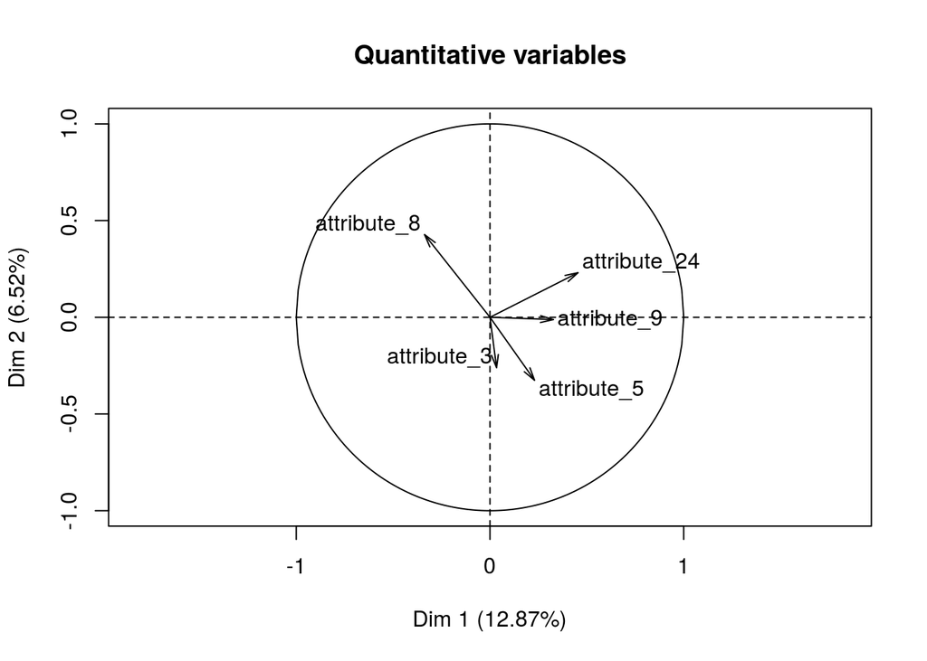

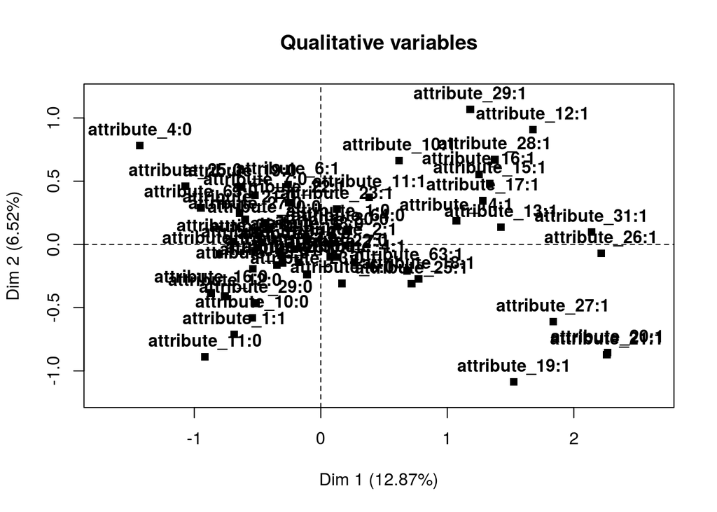

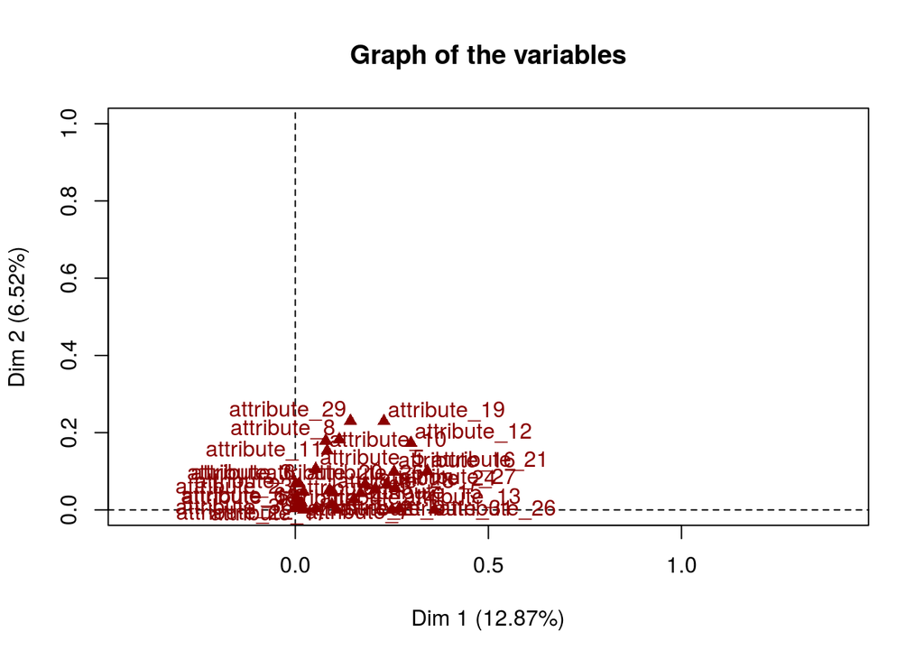

# 3 Determine number of clusters

```
##
##  Only frey, mcclain, cindex, sihouette and dunn can be computed. To compute the other indices, data matrix is needed
```

```
##
##  Only frey, mcclain, cindex, sihouette and dunn can be computed. To compute the other indices, data matrix is needed
```

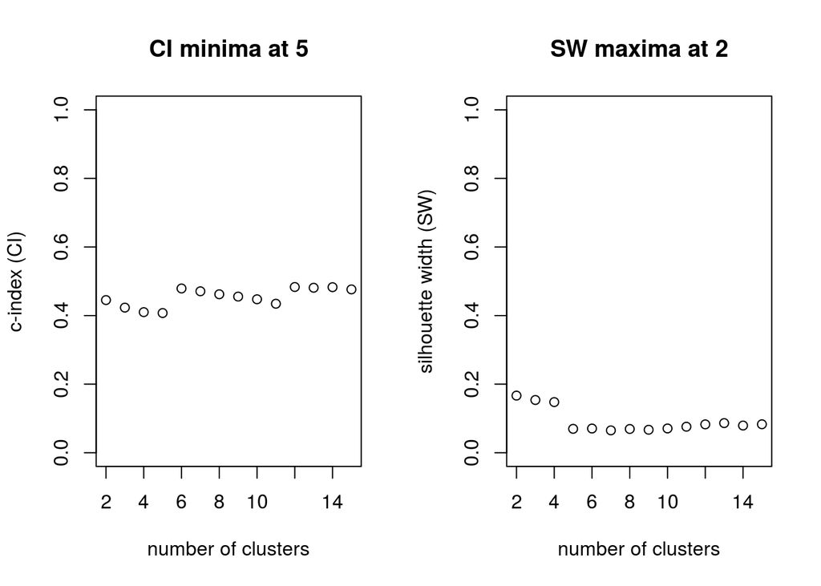

# 4 Clustering

## 4.1 Hierarchical Clustering

Here we use both the optimal number of clusters and observe. Two clusters as indicated by SW is very clear. However, the 5 clusters from CI is also represent true structure of the data. Thus, user can decide at which level of information they prefer to describe their data. For further demostrations, we have, for simplicity, chosen cluster number by CI.

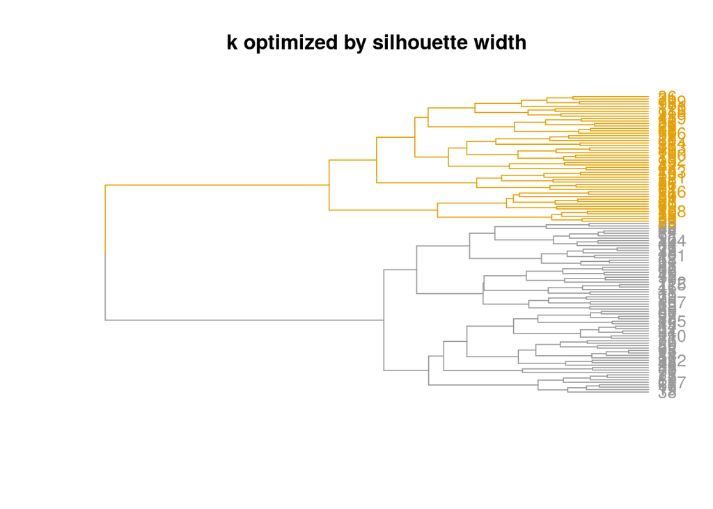

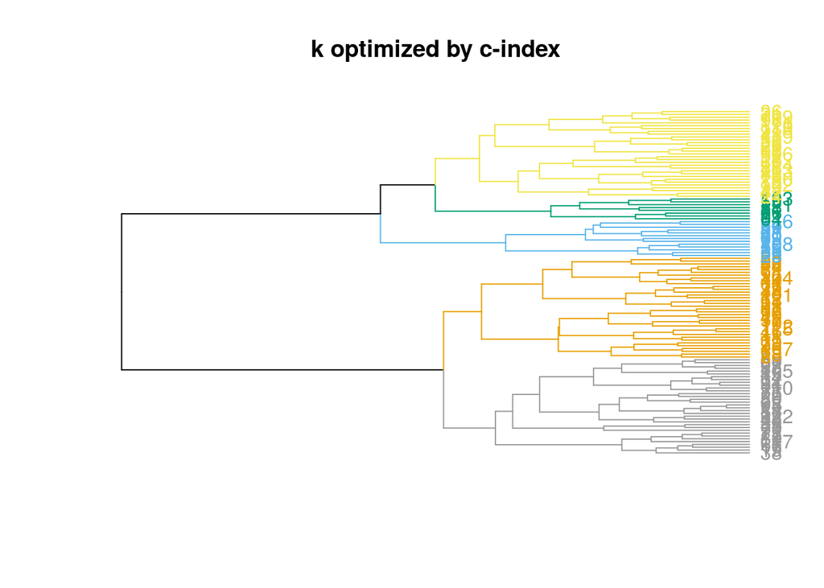

## 4.2 Partition Around Mediods (PAM)

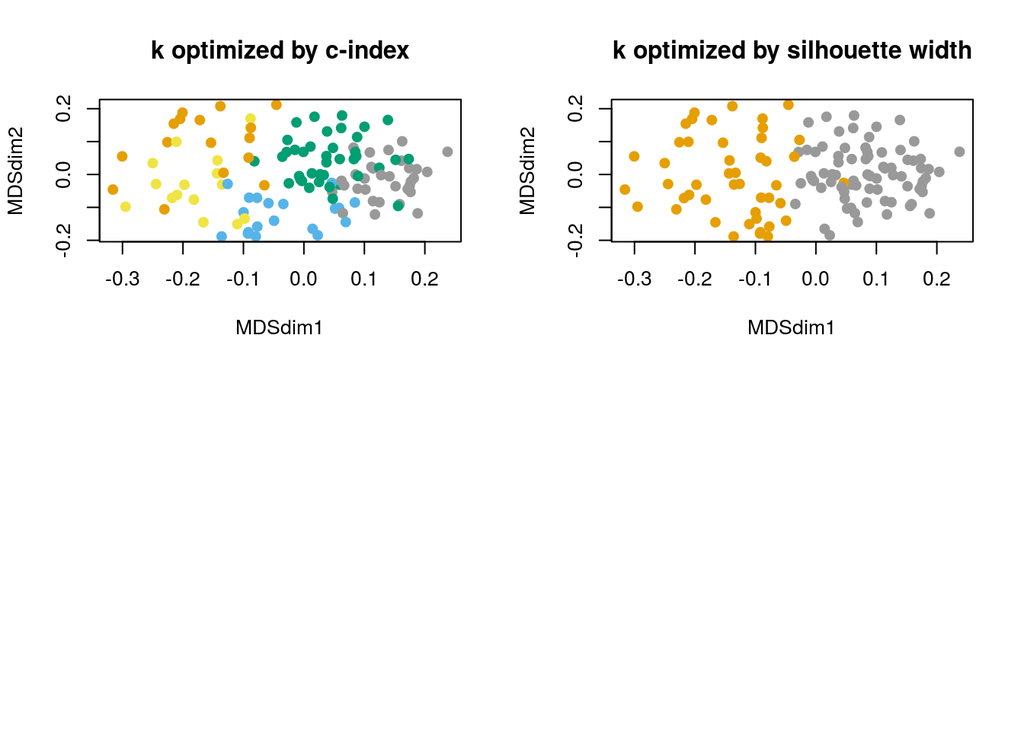

## 4.3 Robustness analysis

Clustering is an unsupervised approach. There is no cross validation to tell us the errors in our model. Thus, we use boostrap approach as implemented in pvclust to observe the robustness in the groups. It shows the dynamics of clusters when a set of samples is removed from the dataset or added to the dataset.

At the same time, most of the times the clusters do not pass this robustness test. It can be attributed to many reasons like low sample size to high overall similarity between the samples. Nevertheless, it is worth trying.

Note: please change the nboot value to 1K to 10K for good evaluation.

[output not shown]

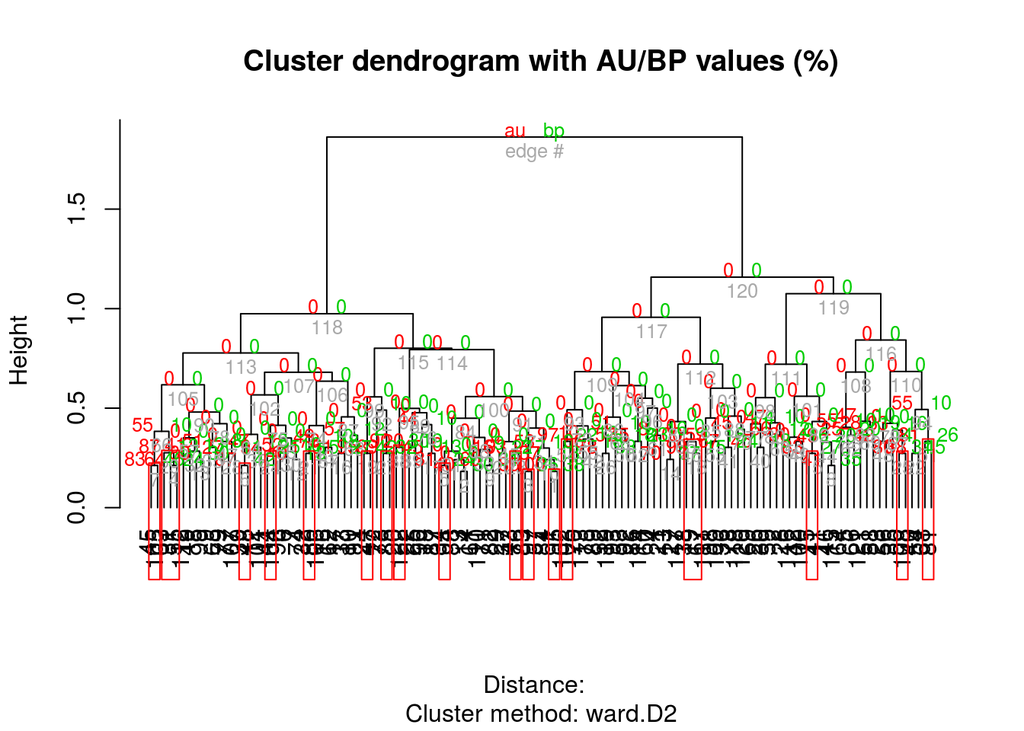

# 5 Non-linear visualization of the clusters

With different perplexity values, one can observe the cluster structure taking shape.

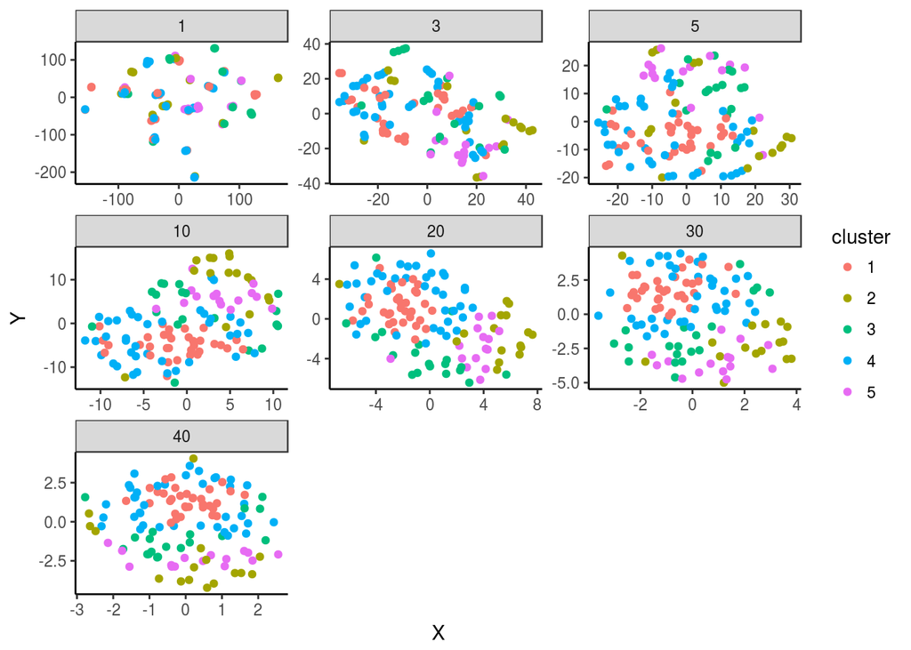

# 6 Cluster Signature

### 6.0.1 Multivariate regression

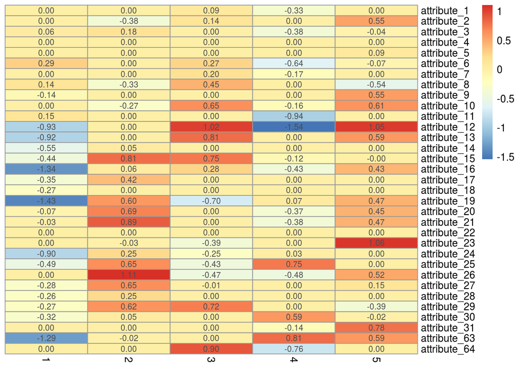

### 6.0.2 Univariate hypothesis testing

| key | statistic | p.value | parameter | method |
| --- | --- | --- | --- | --- |
| attribute_1 | 2.067421 | 7.233599e-01 | 4 | Kruskal-Wallis rank sum test |
| attribute_10 | 20.742966 | 3.560732e-04 | 4 | Kruskal-Wallis rank sum test |
| attribute_11 | 14.022734 | 7.222851e-03 | 4 | Kruskal-Wallis rank sum test |
| attribute_12 | 64.187219 | 3.816512e-13 | 4 | Kruskal-Wallis rank sum test |
| attribute_13 | 32.674135 | 1.392764e-06 | 4 | Kruskal-Wallis rank sum test |
| attribute_14 | 9.679214 | 4.619224e-02 | 4 | Kruskal-Wallis rank sum test |
| attribute_15 | 29.304644 | 6.778853e-06 | 4 | Kruskal-Wallis rank sum test |
| attribute_16 | 41.838972 | 1.801412e-08 | 4 | Kruskal-Wallis rank sum test |
| attribute_17 | 7.529739 | 1.104051e-01 | 4 | Kruskal-Wallis rank sum test |
| attribute_18 | 7.090542 | 1.311802e-01 | 4 | Kruskal-Wallis rank sum test |

[output cut: 23 more lines]

## 6.1 With expression data

### 6.1.1 Multivariate regression

```
## [1] "oops! no variables found here! Check in univariate section"
```

### 6.1.2 Univariate hypothesis testing

| key | statistic | p.value | parameter | method |
| --- | --- | --- | --- | --- |
| attribute_32 | 2.1406660 | 0.70990542 | 4 | Kruskal-Wallis rank sum test |
| attribute_33 | 4.2008590 | 0.37950450 | 4 | Kruskal-Wallis rank sum test |
| attribute_34 | 1.9144062 | 0.75149807 | 4 | Kruskal-Wallis rank sum test |
| attribute_35 | 7.8055567 | 0.09896626 | 4 | Kruskal-Wallis rank sum test |
| attribute_36 | 5.3886398 | 0.24969292 | 4 | Kruskal-Wallis rank sum test |
| attribute_37 | 4.7751423 | 0.31115691 | 4 | Kruskal-Wallis rank sum test |
| attribute_38 | 3.5322095 | 0.47299775 | 4 | Kruskal-Wallis rank sum test |
| attribute_39 | 3.0854029 | 0.54363655 | 4 | Kruskal-Wallis rank sum test |
| attribute_40 | 2.9242579 | 0.57057962 | 4 | Kruskal-Wallis rank sum test |
| attribute_41 | 1.1130391 | 0.89219793 | 4 | Kruskal-Wallis rank sum test |

[output cut: 21 more lines]